# Exploring Results: BMST-01

Last update: 2021-07-29 10:12:48

#### Number of participants: 20

## General Overview

### How accurate are subjects in the task?

The table below shows the average accuracy per subject. Lowest accuracy is listed on top of the table, but feel free to sort by different criteria.

#### Grand Average

|  | subject | score |
| --- | --- | --- |
| 1 | ID 12 | 59.72 |
| 2 | ID 07 | 62.5 |
| 3 | ID 08 | 63.19 |
| 4 | ID 13 | 70.14 |
| 5 | ID 04 | 73.61 |
| 6 | ID 03 | 75.69 |
| 7 | ID 09 | 75.69 |
| 8 | ID 18 | 75.69 |
| 9 | ID 10 | 76.39 |
| 10 | ID 19 | 76.39 |

[output cut: 10 more lines]

#### By Condition

|  | subject | standard | difference_type | score |
| --- | --- | --- | --- | --- |
| 1 | ID 07 | square | longer | 30.56 |
| 2 | ID 07 | human | longer | 50 |
| 3 | ID 12 | human | longer | 50 |
| 4 | ID 12 | square | longer | 52.78 |
| 5 | ID 09 | square | longer | 55.56 |
| 6 | ID 13 | square | longer | 55.56 |
| 7 | ID 02 | square | shorter | 58.33 |
| 8 | ID 08 | human | shorter | 58.33 |
| 9 | ID 13 | human | longer | 58.33 |
| 10 | ID 05 | square | longer | 61.11 |

[output cut: 70 more lines]

**Grand Average**: Average accuracy across all trials per subject. Apart from the first 3 participants, who are all around an average accuracy of ~60, participants were able to accomplish the task well above chance level.

**By Condition**: When calculating the accuracy separately for the different conditions, there is a more complicated picture: some participants had difficulties when the 2nd stimulus was longer, but not when it was shorter (see e.g. `ID 07`).

Let’s use some graphical representations to get a better glimpse of the response distributions in general and (further below) on the subject-level.

### How are responses distributed?

As a reminder and to make reading the plot easier: Each trial consisted of two consecutive videos. After the second video was displayed, participants were asked to judge if *the 2nd video was shorter or longer than the 1st*. The answering scale ranged from 0 (*certainly shorter*) to 101 (*certainly longer*).

In the following plot we see all answers, split by

| Variable *{levels}* | Encoding |
| --- | --- |
| Type of standard *{moving, still}* | X-axis |
| Type of difference *{longer, shorter}* | Panels |
| Standard *{human, square}* | Colour |

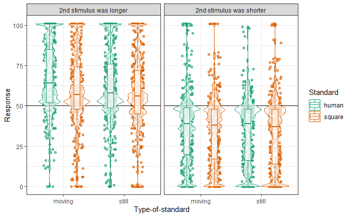

We can observe that in general the center of the distribution is on the correct side of the middle line (`y = 50`). I.e. in the left panel for all trials where the 2nd stimulus was longer, the majority of responses is higher than 50. Conversely, in the right panel where the 2nd stimulus was shorter, the majority is below 50. It seems like the center of the distribution is more clearly in the correct half of the plot in the case of the shorter 2nd stimulus, as indicated by the interquartile range (IQR) of the boxplots. In the left panel the IQR overlaps with the 50-mark.

We note also that in **all** cases (violins/boxplots/dots) we see quite some spread around the center of the distribution. Maybe a little less so in the right panel.

When looking at the different conditions (encoded in colour and on the x-axis), we can see rather similar patterns.

Specifically looking at the comparisons of the `standard` (colour-encoded), there may be a trend such that the square leads to more responses in the `shorter` direction (i.e. lower values on the y-axis). At least in the left-most comparison this is visible. The comparisons in the right panel don’t look like there is such a trend.

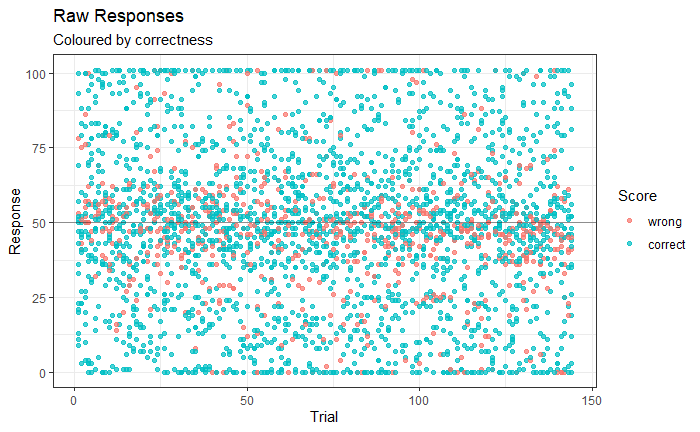

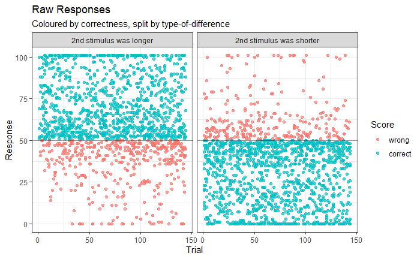

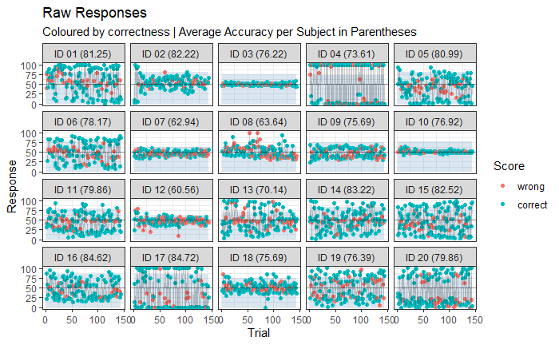

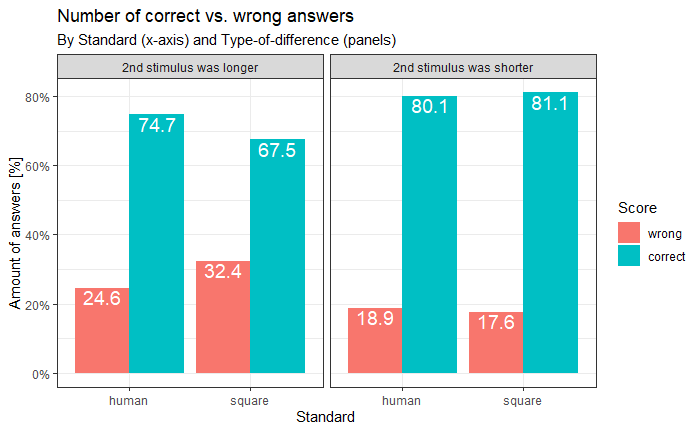

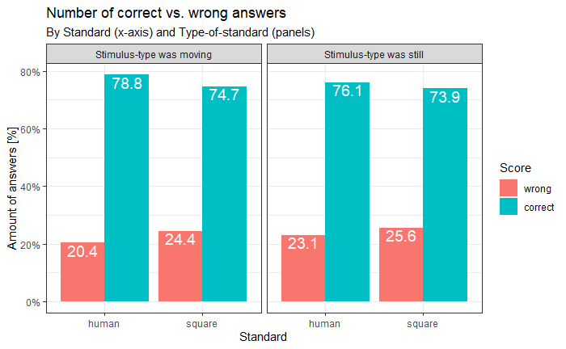